# Customer Personality Analysis

Group 7 - Isaac Yang, Pengxiang Chen, Raihan Putra, Zhiqi Rui

12/09/2021

# Introduction

Customer personality analysis is a detailed analysis done by a brand or company to find an ideal set of customers. This helps the company to make changes in their product and marketing in a more efficient way. Promoting a product to a customer who is more likely to buy the product is better than promoting it to a random person.

Customer personality analysis is done by clustering as it is an unsupervised problem.

```r
library(dplyr)
```

```r
library(ggplot2)
library(cluster)
library(gower)
library(Rtsne)
library(stringr)
library(corrgram)
```

# Data

```r
data <- read.csv2("../data/marketing_campaign.csv", sep = "\t")

sum(is.na(data))
```

```
## [1] 24
```

```r
data <- na.omit(data)
```

As there are very few NA items we will just omit them.

```r
str(data)
```

```
## 'data.frame':    2216 obs. of  29 variables:
##  $ ID                 : int  5524 2174 4141 6182 5324 7446 965 6177 4855 5899 ...
##  $ Year_Birth         : int  1957 1954 1965 1984 1981 1967 1971 1985 1974 1950 ...
##  $ Education          : chr  "Graduation" "Graduation" "Graduation" "Graduation" ...
##  $ Marital_Status     : chr  "Single" "Single" "Together" "Together" ...
##  $ Income             : int  58138 46344 71613 26646 58293 62513 55635 33454 30351 5648 ...
##  $ Kidhome            : int  0 1 0 1 1 0 0 1 1 1 ...
##  $ Teenhome           : int  0 1 0 0 0 1 1 0 0 1 ...
##  $ Dt_Customer        : chr  "04-09-2012" "08-03-2014" "21-08-2013" "10-02-2014" ...
##  $ Recency            : int  58 38 26 26 94 16 34 32 19 68 ...
##  $ MntWines           : int  635 11 426 11 173 520 235 76 14 28 ...
##  $ MntFruits          : int  88 1 49 4 43 42 65 10 0 0 ...
##  $ MntMeatProducts    : int  546 6 127 20 118 98 164 56 24 6 ...
##  $ MntFishProducts    : int  172 2 111 10 46 0 50 3 3 1 ...
##  $ MntSweetProducts   : int  88 1 21 3 27 42 49 1 3 1 ...
```

[output cut: 17 more lines]

The data is mixed type data (i.e. both categorical and continuous values). Euclidean distance is commonly used for clustering algorithms like KMeans and hierarchical clustering but it is useful when we only have to deal with continuous values. Thus, we will use Gower distance as the distance metric.

Gower distance is computed as the average of partial dissimilarities across individuals. Each partial dissimilarity (and thus Gower distance) ranges in [0 1].

# Data Cleaning

To work with the data we need to alter some variables and add a few new variables based on the existing ones.

1. Year_Birth, changing it to the Age variable.

```r
data$Age <- 2014 - data$Year_Birth
```

2. Education, it has too many categories this can be converted to UG and PG categories.

```r
data$Education[data$Education == "2n Cycle"] = "UG"
data$Education[data$Education == "Basic"] = "UG"
data$Education[data$Education == "Graduation"] = "PG"
data$Education[data$Education == "Master"] = "PG"
data$Education[data$Education == "PhD"] = "PG"
```

3. Marital_Status, it also has many categories which can be converted to Single and Couple categories.

```r
data$Marital_Status[data$Marital_Status == "Divorced"] = "Single"
data$Marital_Status[data$Marital_Status == "Absurd"] = "Single"
data$Marital_Status[data$Marital_Status == "YOLO"] = "Single"
data$Marital_Status[data$Marital_Status == "Widow"] = "Single"
data$Marital_Status[data$Marital_Status == "Together"] = "Couple"
data$Marital_Status[data$Marital_Status == "Married"] = "Couple"
data$Marital_Status[data$Marital_Status == "Alone"] = "Single"
```

4. Dt_Customer, the customer association date with the company can be changed to a seniority level.

```r
data$Customer_year <- str_sub(data$Dt_Customer, -4)
data$Customer_year <- as.numeric(data$Customer_year)
data$Customer_Seniority <- 2014 - data$Customer_year
```

5. Kidhome and Teenhome, we feel that the Kidhome and Teenhome variables can collectively define the child variable.

```r
data$Child <- data$Kidhome + data$Teenhome
```

6. Mnt products, the amount spend of products can be added together to get the total amount spent which will be a more useful variable.

```r
data$Amt_Spent <-
  data$MntWines + data$MntFishProducts + data$MntFruits + data$MntGoldProds + data$MntMeatProducts + data$MntSweetProducts
```

7. Num_Purchases_made, we can get the total number of purchases by adding the different purchases variables.

```r
data$Num_Purchases_made <-
  data$NumWebPurchases + data$NumCatalogPurchases + data$NumStorePurchases
```

8. Thus, we are left with 12 variables that can be used to create the distance matrix.

```r
data <- data[c(1, 30, 3, 4, 5, 33, 32, 9, 34, 35, 16, 20)]
```

# Exploratory Data Analysis

## Corrgram

```r
data2 <- data
data2$Education <- unclass(as.factor(data2$Education))
data2$Marital_Status <- unclass(as.factor(data2$Marital_Status))
data2$Education <- as.numeric(data2$Education)
data2$Marital_Status <- as.numeric(data2$Marital_Status)
corrgram(
  data2[-c(1)],
  order = TRUE,
  lower.panel = panel.shade,
  upper.panel = NULL,
  text.panel = panel.txt,
  main = "Customer Data"
)
```

[figure not shown]

Strong Correlation between Income, Amount Spent and Purchase, as well as slight trend between Education and Income (PG: 1, UG: 2) tells us that people with higher studies earn more.

1. Age

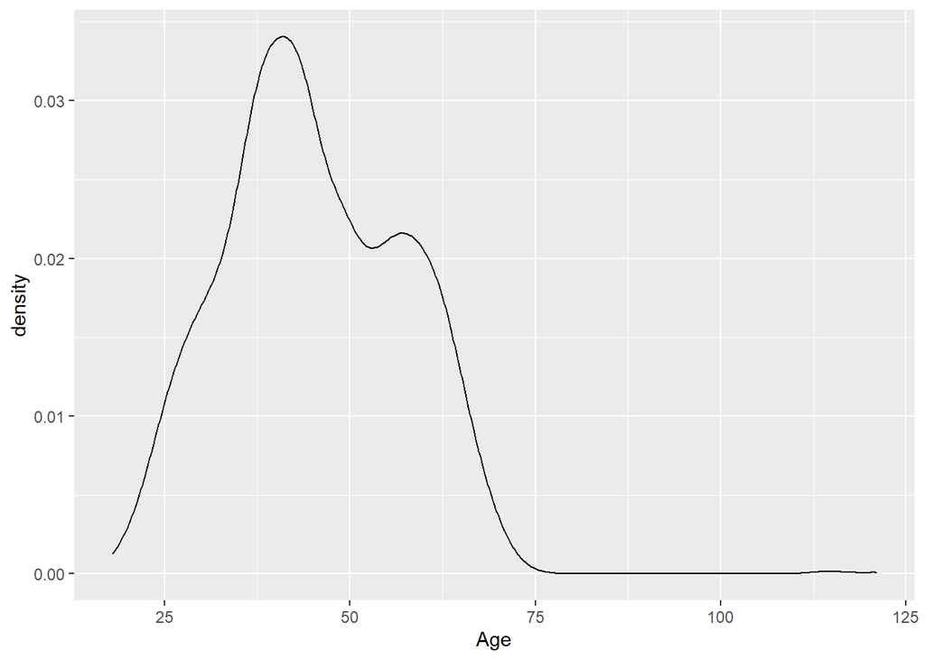

```r
age_plot <- ggplot(data = data, aes(Age))
age_plot + geom_density()
```

2. Education

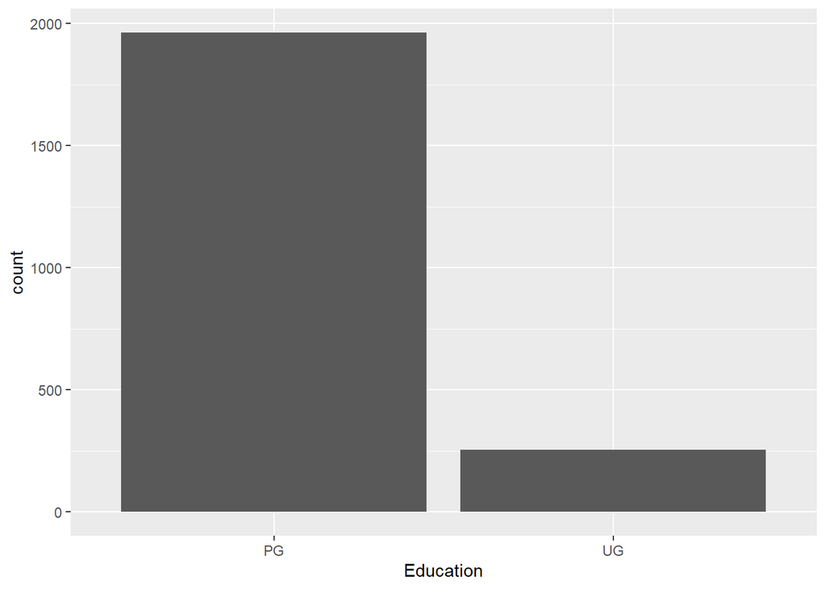

```r
edu_plot1 <- ggplot(data = data, aes(Education))
edu_plot1 + geom_histogram(stat = "count")
```

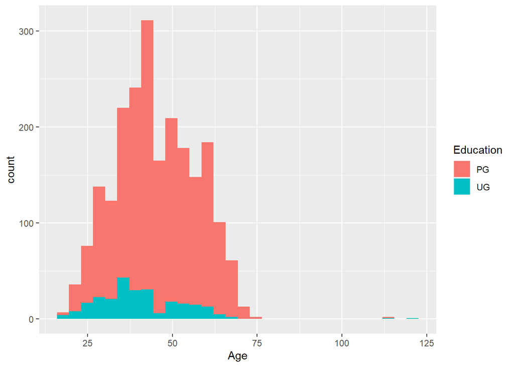

```r
edu_plot2 <- ggplot(data = data, aes(Age, fill = Education))
edu_plot2 + geom_histogram()
```

3. Marital Status

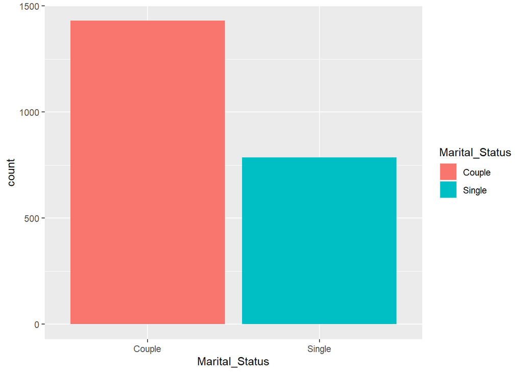

```r
marital_plot <-
  ggplot(data = data, aes(Marital_Status, fill = Marital_Status))
marital_plot + geom_histogram(stat = "count")
```

4. Income & Amount Spent

```r
require(scales)
```

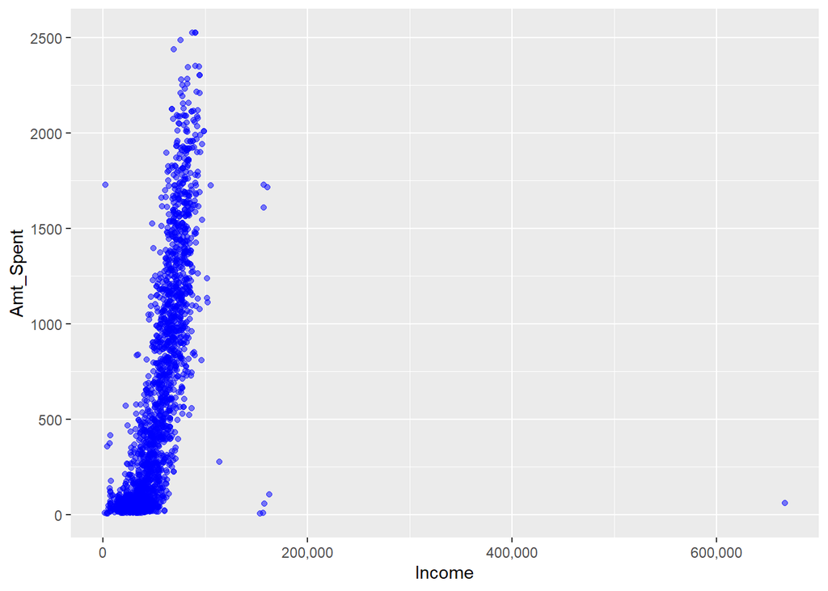

```r
inc_plt <- ggplot(data = data, aes(Income, Amt_Spent))
inc_plt + geom_point(alpha = 0.5, color = "blue") + scale_x_continuous(labels = comma)
```

5. Child

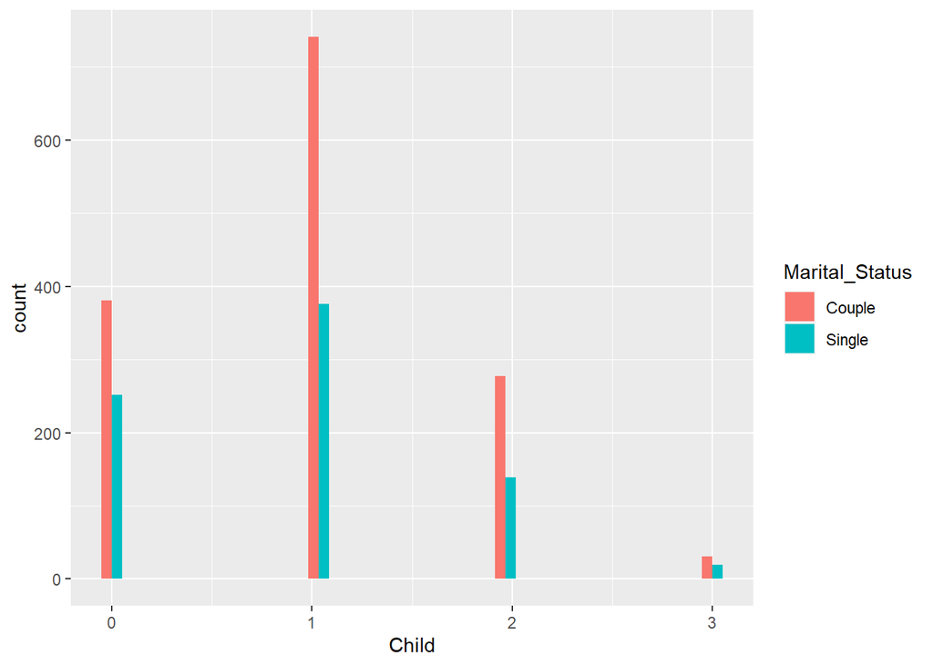

```r
a <- ggplot(data = data,  aes(Child, fill = Marital_Status))
a + geom_histogram(position = "dodge")
```

6. Customer Seniority & Amount Spent

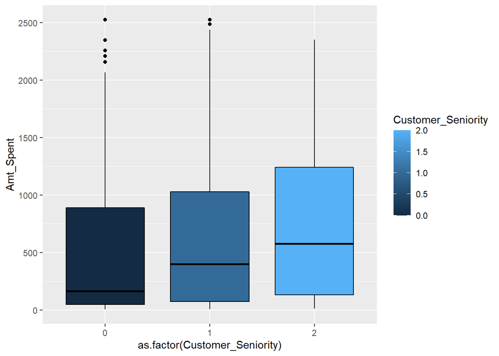

```r
cust_plt <-
  ggplot(data = data, aes(as.factor(Customer_Seniority), Amt_Spent, fill = Customer_Seniority))

cust_plt + geom_boxplot(color = "black")
```

# Analysis

## Analysis based on income, seniority, age, and amount spent.

```r
gower_dist2 <-
  daisy(data[c("Income", "Amt_Spent", "Customer_Seniority", "Age")],
        metric = "gower")

summary(gower_dist2)
```

```
## 2454220 dissimilarities, summarized :
##    Min. 1st Qu.  Median    Mean 3rd Qu.    Max.
##  0.0000  0.1234  0.1902  0.1973  0.2686  0.7065
## Metric :  mixed ;  Types = I, I, I, I
## Number of objects : 2216
```

```r
gower_mat2 <- as.matrix(gower_dist2)
```

### Most similar pair

```r
data[which(gower_mat2 == min(gower_mat2[gower_mat2 != min(gower_mat2)]),
           arr.ind = TRUE)[1,],]
```

```
##         ID Age Education Marital_Status Income Child Customer_Seniority Recency
## 1754  5092  65        PG         Single  51569     1                  1      39
## 438  10664  65        PG         Single  51529     1                  1      14
##      Amt_Spent Num_Purchases_made NumDealsPurchases NumWebVisitsMonth
## 1754       467                 15                 4                 8
## 438        467                 15                 2                 8
```

### Most dissimilar pair

```r
data[which(gower_mat2 == max(gower_mat2[gower_mat2 != max(gower_mat2)]),
           arr.ind = TRUE)[1,],]
```

```
##        ID Age Education Marital_Status Income Child Customer_Seniority Recency
## 915 10619  20        PG         Single  95529     0                  2      29
## 240 11004 121        UG         Single  60182     1                  0      23
##     Amt_Spent Num_Purchases_made NumDealsPurchases NumWebVisitsMonth
## 915      1990                 17                 1                 3
## 240        22                  3                 1                 4
```

### Finding number of clusters

```r
sil_width2 <- c(NA)

for (i in 2:10) {
  pam_fit2 <- pam(gower_dist2,
                  diss = TRUE,
                  k = i)

  sil_width2[i] <- pam_fit2$silinfo$avg.width

}
```

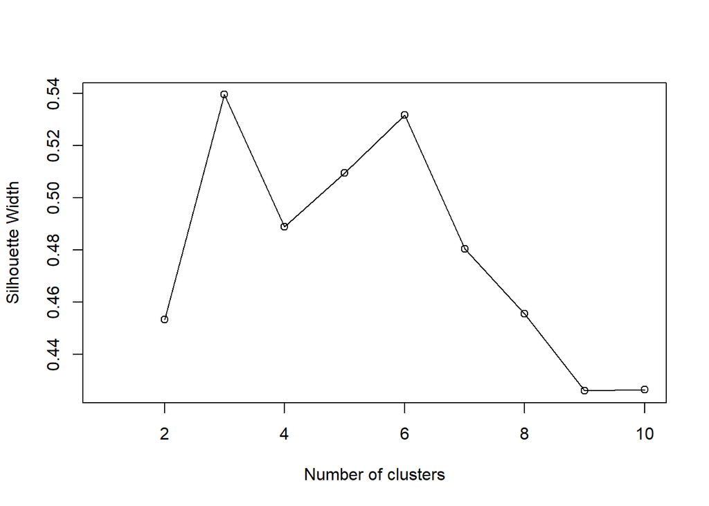

```r
plot(1:10, sil_width2,
     xlab = "Number of clusters",
     ylab = "Silhouette Width")
lines(1:10, sil_width2)
```

### Cluster summary

```r
pam_fit2 <- pam(gower_dist2, diss = TRUE, k = 4)

pam_results2 <- data %>%
  dplyr::select(
    -c(
      ID,
      Child,
      NumWebVisitsMonth,
      Num_Purchases_made,
      NumDealsPurchases,
      Education,
      Marital_Status
    )
  ) %>%
  mutate(cluster = pam_fit2$clustering) %>%
  group_by(cluster) %>%
  do(the_summary = summary(.))

pam_results2$the_summary
```

```
## [[1]]
##       Age            Income       Customer_Seniority    Recency
##  Min.   :18.00   Min.   :  6835   Min.   :2          Min.   : 0.00
##  1st Qu.:36.00   1st Qu.: 34217   1st Qu.:2          1st Qu.:26.00
##  Median :43.00   Median : 52050   Median :2          Median :50.50
##  Mean   :44.17   Mean   : 51150   Mean   :2          Mean   :50.11
##  3rd Qu.:54.00   3rd Qu.: 67441   3rd Qu.:2          3rd Qu.:76.00
##  Max.   :69.00   Max.   :160803   Max.   :2          Max.   :99.00
##    Amt_Spent         cluster
##  Min.   :  13.0   Min.   :1
##  1st Qu.: 132.2   1st Qu.:1
##  Median : 578.5   Median :1
##  Mean   : 746.6   Mean   :1
##  3rd Qu.:1240.8   3rd Qu.:1
##  Max.   :2352.0   Max.   :1
##
## [[2]]
##       Age             Income       Customer_Seniority    Recency
##  Min.   : 18.00   Min.   :  1730   Min.   :0          Min.   : 0.00
##  1st Qu.: 37.00   1st Qu.: 35246   1st Qu.:0          1st Qu.:23.00
##  Median : 44.00   Median : 51287   Median :0          Median :47.00
##  Mean   : 45.18   Mean   : 52827   Mean   :0          Mean   :47.83
##  3rd Qu.: 55.00   3rd Qu.: 70545   3rd Qu.:0          3rd Qu.:73.00
##  Max.   :121.00   Max.   :157243   Max.   :0          Max.   :99.00
##    Amt_Spent         cluster
##  Min.   :   6.0   Min.   :2
##  1st Qu.:  49.0   1st Qu.:2
##  Median : 165.0   Median :2
##  Mean   : 493.8   Mean   :2
##  3rd Qu.: 889.0   3rd Qu.:2
##  Max.   :2525.0   Max.   :2
##
## [[3]]
##       Age             Income       Customer_Seniority    Recency
##  Min.   : 21.00   Min.   :  2447   Min.   :1          Min.   : 0.00
##  1st Qu.: 39.00   1st Qu.: 62745   1st Qu.:1          1st Qu.:24.00
##  Median : 49.00   Median : 70379   Median :1          Median :51.00
##  Mean   : 48.25   Mean   : 70493   Mean   :1          Mean   :49.63
##  3rd Qu.: 59.00   3rd Qu.: 78353   3rd Qu.:1          3rd Qu.:74.00
##  Max.   :115.00   Max.   :157146   Max.   :1          Max.   :99.00
```

[output cut: 8 more lines]

```
## [[4]]
##       Age             Income       Customer_Seniority    Recency
##  Min.   : 22.00   Min.   :  3502   Min.   :1          Min.   : 0.00
##  1st Qu.: 36.00   1st Qu.: 28437   1st Qu.:1          1st Qu.:25.00
##  Median : 42.00   Median : 38199   Median :1          Median :49.00
##  Mean   : 43.69   Mean   : 39338   Mean   :1          Mean   :48.74
##  3rd Qu.: 51.00   3rd Qu.: 47497   3rd Qu.:1          3rd Qu.:74.00
##  Max.   :114.00   Max.   :666666   Max.   :1          Max.   :99.00
##    Amt_Spent        cluster
##  Min.   :  5.0   Min.   :4
##  1st Qu.: 46.0   1st Qu.:4
##  Median : 91.0   Median :4
##  Mean   :168.4   Mean   :4
##  3rd Qu.:268.2   3rd Qu.:4
##  Max.   :662.0   Max.   :4
```

We can interpret from the cluster summary that 4 types of customers here are:

- Cluster 1: Avg Income | Senior Customers | Spending Avg Amount
- Cluster 2: Avg Income | New Customers | Avg Spending less than Cluster 1 customers
- Cluster 3: High Income | Fairly Senior Customers | High Avg Spending
- Cluster 4: Below Avg Income | Fairly Senior Customers | Low Avg Spending

### Visualizing cluster

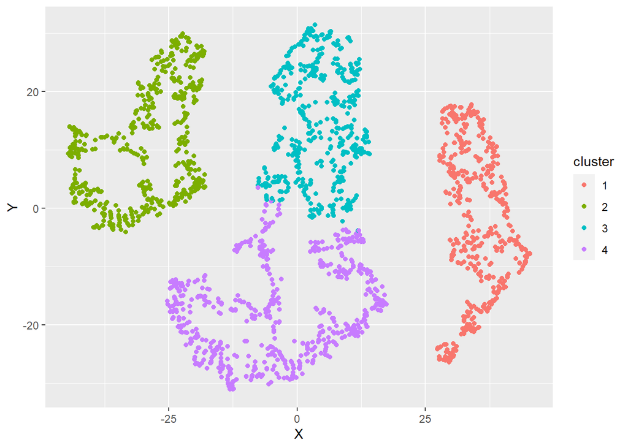

```r
tsne_obj2 <- Rtsne(gower_dist2, is_distance = TRUE)

tsne_data2 <- tsne_obj2$Y %>%
  data.frame() %>%
  setNames(c("X", "Y")) %>%
  mutate(cluster = factor(pam_fit2$clustering),
         name = data$ID)

ggplot(aes(x = X, y = Y), data = tsne_data2) +
  geom_point(aes(color = cluster))
```

## Analysis based on item purchased, amount spent, number of child, and marital status.

```r
data2 <- data

data2$Education <- unclass(as.factor(data2$Education))

data2$Marital_Status <- unclass(as.factor(data2$Marital_Status))

data2$Education <- as.numeric(data2$Education)

data2$Marital_Status <- as.numeric(data2$Marital_Status)

data_new <- read.csv2("../data/marketing_campaign.csv", sep = "\t")
data_new <- na.omit(data_new)

data3 <- data2
data3$AmtWines <- data_new$MntWines
data3$AmtFruits <- data_new$MntFruits
data3$AmtFish <- data_new$MntFishProducts
data3$AmtMeat <- data_new$MntMeatProducts
data3$AmtSweet <- data_new$MntSweetProducts
data3$AmtGold <- data_new$MntGoldProds
data3$Education <- as.factor(data3$Education)
data3$Marital_Status <- as.factor(data3$Marital_Status)
```

```r
gower_dist3 <-
  daisy(data3[c(
    "Income",
    "Child",
    "Num_Purchases_made",
    "Marital_Status",
    "AmtWines",
    "AmtFruits",
    "AmtFish",
    "AmtMeat",
    "AmtSweet",
    "AmtGold",
    "NumDealsPurchases",
    "Amt_Spent",
    "Recency"
  )],
  metric = "gower")

summary(gower_dist3)
```

```
## 2454220 dissimilarities, summarized :
##    Min. 1st Qu.  Median    Mean 3rd Qu.    Max.
##  0.0000  0.1422  0.2075  0.2135  0.2796  0.6256
## Metric :  mixed ;  Types = I, I, I, N, I, I, I, I, I, I, I, I, I
## Number of objects : 2216
```

```r
gower_mat3 <- as.matrix(gower_dist3)
```

### Most similar pair

```r
data3[which(gower_mat3 == min(gower_mat3[gower_mat3 != min(gower_mat3)]),
            arr.ind = TRUE)[1, ], ]
```

```
##        ID Age Education Marital_Status Income Child Customer_Seniority Recency
## 1469 7196  64         1              1  41145     2                  0      20
## 570  3525  44         1              1  38200     2                  2      19
##      Amt_Spent Num_Purchases_made NumDealsPurchases NumWebVisitsMonth AmtWines
## 1469        13                  3                 1                 3        9
## 570         17                  3                 1                 7       12
##      AmtFruits AmtFish AmtMeat AmtSweet AmtGold
## 1469         0       0       3        0       1
## 570          0       0       4        0       1
```

### Most dissimilar pair

```r
data3[which(gower_mat3 == max(gower_mat3[gower_mat3 != max(gower_mat3)]),
            arr.ind = TRUE)[1, ], ]
```

```
##        ID Age Education Marital_Status Income Child Customer_Seniority Recency
## 1445 1553  68         1              1  82657     0                  1      71
## 161  2795  56         1              2  30523     3                  1       0
##      Amt_Spent Num_Purchases_made NumDealsPurchases NumWebVisitsMonth AmtWines
## 1445      2283                 22                 1                 4      966
## 161         13                  3                 1                 7        5
##      AmtFruits AmtFish AmtMeat AmtSweet AmtGold
## 1445       168     246     672      105     126
## 161          0       0       3        0       5
```

### Finding number of clusters

```r
sil_width3 <- c(NA)

for (i in 2:10) {
  pam_fit3 <- pam(gower_dist3,
                  diss = TRUE,
                  k = i)

  sil_width3[i] <- pam_fit3$silinfo$avg.width

}
```

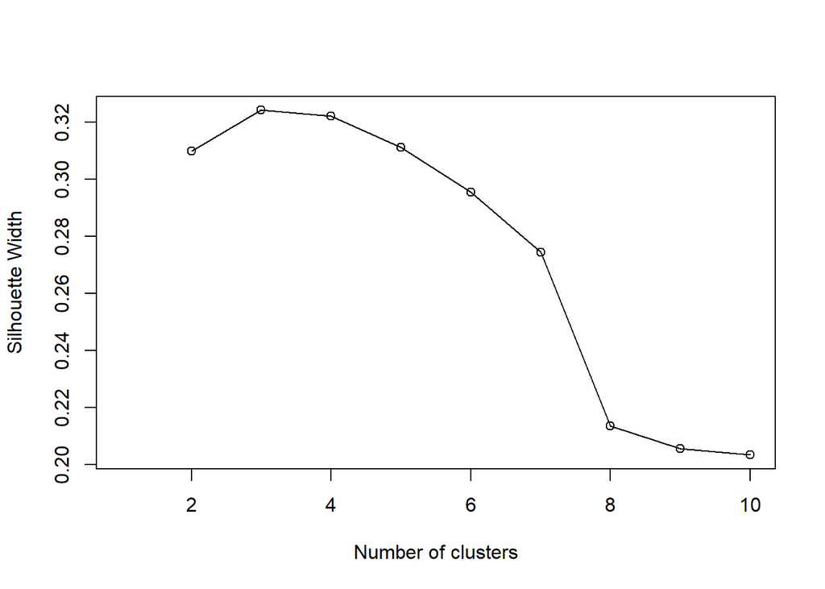

```r
plot(1:10, sil_width3,
     xlab = "Number of clusters",
     ylab = "Silhouette Width")
lines(1:10, sil_width3)
```

### Cluster summary

```r
pam_fit3 <- pam(gower_dist3, diss = TRUE, k = 3)

pam_results3 <- data3 %>%
  dplyr::select(-c(ID, NumWebVisitsMonth, Age, Customer_Seniority)) %>%
  mutate(cluster = pam_fit3$clustering) %>%
  group_by(cluster) %>%
  do(the_summary = summary(.))

pam_results3$the_summary
```

```
## [[1]]
##  Education Marital_Status     Income           Child           Recency
##  1:563     1:433          Min.   : 32632   Min.   :0.0000   Min.   : 0.00
##  2: 60     2:190          1st Qu.: 68109   1st Qu.:0.0000   1st Qu.:25.00
##                           Median : 75012   Median :0.0000   Median :52.00
##                           Mean   : 74363   Mean   :0.3451   Mean   :49.67
##                           3rd Qu.: 81187   3rd Qu.:1.0000   3rd Qu.:74.00
##                           Max.   :105471   Max.   :3.0000   Max.   :99.00
##    Amt_Spent    Num_Purchases_made NumDealsPurchases    AmtWines
##  Min.   : 461   Min.   : 9.00      Min.   : 0.00     Min.   :  47.0
##  1st Qu.:1072   1st Qu.:17.00      1st Qu.: 1.00     1st Qu.: 397.5
##  Median :1338   Median :20.00      Median : 1.00     Median : 587.0
##  Mean   :1381   Mean   :19.98      Mean   : 1.66     Mean   : 639.3
##  3rd Qu.:1653   3rd Qu.:23.00      3rd Qu.: 2.00     3rd Qu.: 854.0
##  Max.   :2525   Max.   :32.00      Max.   :15.00     Max.   :1493.0
##    AmtFruits        AmtFish          AmtMeat         AmtSweet
##  Min.   :  0.0   Min.   :  0.00   Min.   : 48.0   Min.   :  0.00
##  1st Qu.: 27.0   1st Qu.: 45.00   1st Qu.:242.0   1st Qu.: 30.00
##  Median : 58.0   Median : 86.00   Median :397.0   Median : 56.00
##  Mean   : 68.3   Mean   : 98.18   Mean   :425.5   Mean   : 69.32
##  3rd Qu.:102.0   3rd Qu.:145.00   3rd Qu.:568.5   3rd Qu.:102.00
##  Max.   :199.0   Max.   :259.00   Max.   :984.0   Max.   :198.00
##     AmtGold          cluster
##  Min.   :  0.00   Min.   :1
##  1st Qu.: 33.00   1st Qu.:1
##  Median : 61.00   Median :1
##  Mean   : 80.41   Mean   :1
##  3rd Qu.:118.50   3rd Qu.:1
##  Max.   :249.00   Max.   :1
##
## [[2]]
##  Education Marital_Status     Income           Child          Recency
##  1:529     1:  0          Min.   :  1730   Min.   :0.000   Min.   : 0.00
##  2: 67     2:596          1st Qu.: 31631   1st Qu.:1.000   1st Qu.:25.00
##                           Median : 43103   Median :1.000   Median :49.00
##                           Mean   : 44460   Mean   :1.117   Mean   :48.13
##                           3rd Qu.: 57102   3rd Qu.:2.000   3rd Qu.:73.00
##                           Max.   :153924   Max.   :3.000   Max.   :99.00
##    Amt_Spent      Num_Purchases_made NumDealsPurchases    AmtWines
##  Min.   :   5.0   Min.   : 0.00      Min.   : 0.00     Min.   :   0.0
```

[output cut: 34 more lines]

```
##  Max.   :1730   Max.   :29.000     Max.   :15.000    Max.   :1279.0
##    AmtFruits          AmtFish          AmtMeat           AmtSweet
##  Min.   :  0.000   Min.   :  0.00   Min.   :   1.00   Min.   :  0.00
##  1st Qu.:  1.000   1st Qu.:  2.00   1st Qu.:  11.00   1st Qu.:  1.00
##  Median :  4.000   Median :  6.00   Median :  25.00   Median :  4.00
##  Mean   :  8.186   Mean   : 11.98   Mean   :  59.11   Mean   :  9.25
##  3rd Qu.: 10.000   3rd Qu.: 15.00   3rd Qu.:  73.00   3rd Qu.: 11.00
##  Max.   :123.000   Max.   :179.00   Max.   :1725.00   Max.   :195.00
##     AmtGold          cluster
##  Min.   :  0.00   Min.   :3
##  1st Qu.:  6.00   1st Qu.:3
##  Median : 14.00   Median :3
##  Mean   : 27.43   Mean   :3
##  3rd Qu.: 32.00   3rd Qu.:3
##  Max.   :321.00   Max.   :3
```

We can interpret from the cluster summary that 3 types of customers here are:

- Cluster 1: Couple or Not Single people | More Post Graduates | Higher than Avg Income | Highest Buyer of Wine & Meat | Gold Purchase also Above Avg | Overall Purchase and Amount Spent also Highest
- Cluster 2: Singles | Post Graduates | Avg Income | Below Avg Amount Spent | Greater Deal Purchases than Cluster One Customers
- Cluster 3: Couples | Mostly Post Graduates (But also includes relatively higher number of Undergrads compared to other clusters) | Below Avg Income | Low Amount Spent | More Deal focused Purchases | Would prefer essentials over leisure (Gold and Sweets)

### Visualizing cluster

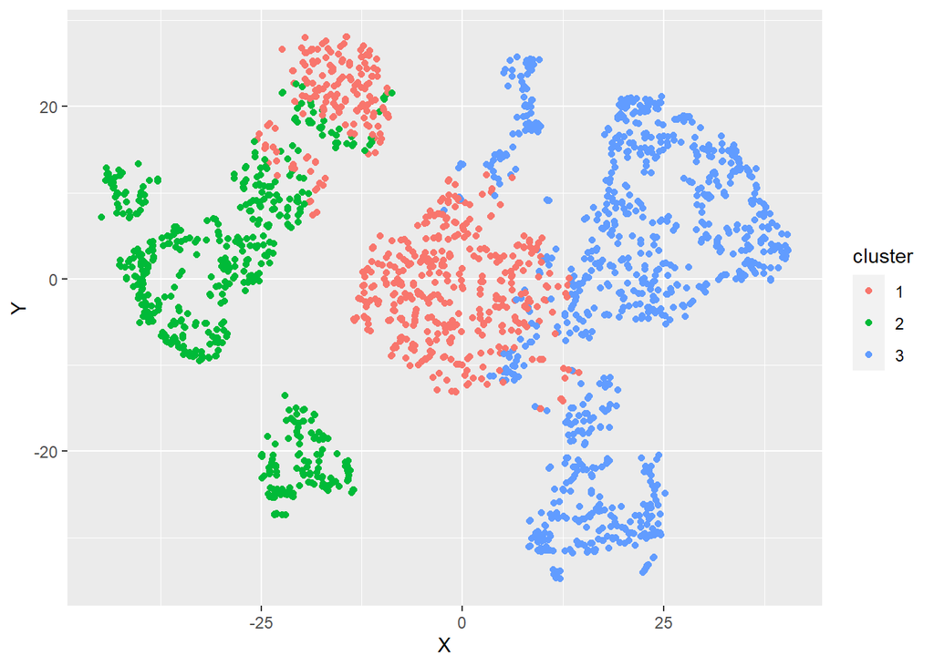

```r
tsne_obj3 <- Rtsne(gower_dist3, is_distance = TRUE)

tsne_data3 <- tsne_obj3$Y %>%
  data.frame() %>%
  setNames(c("X", "Y")) %>%
  mutate(cluster = factor(pam_fit3$clustering),
         name = data3$ID)

ggplot(aes(x = X, y = Y), data = tsne_data3) +
  geom_point(aes(color = cluster))
```

# Conclusion

1. New and old customers with avg income and fairly avg amount spent should be more focused on, provide better advertising and deals to them.
2. If a new non-discounted expensive item will be up for sale, ads should be targeted better to customers with high spending nature and income.
3. Customers with low spending natures and low incomes should be targeted with flash deals and discounts on essentials like fish, fruits, and meat to keep them engaged with the company.
4. Customers tend to spend and purchase more on wine and meat so this products can be worked upon such as more deals and more variability on the product to benefit the company.
5. Senior customers should be engaged with the company in other ways such as memberships or specific deals, this will increase improve relationship with company.